# Gene sets in R

## An example of a goseq analysis

### Load the data

Here we load the example frmo the `goseq` package.

```r
temp_data =read.table(system.file("extdata","Li_sum.txt",
                                  package="goseq"),sep="\t",
                      header=TRUE,
                      stringsAsFactors=FALSE)
expr= temp_data[,-1]
rownames(expr) = temp_data[,1]
expr = expr[rowMeans(expr) > 5,]
grp=factor(rep(c("Control","Treated"),times=c(4,3)))
pdata  = data.frame(grp)
```

### Perform a differential expression analysis

Now we perform a differential expression analysis for the group variable with `DESeq2`

```r
de = DESeqDataSetFromMatrix(expr, pdata, ~grp)
de_fit = DESeq(de)
de_results = results(de_fit)
```

Get the differentially expressed genes after FDR correction

```r
genes = as.integer(de_results$padj < 0.05)
not_na = !is.na(genes)
names(genes) = rownames(expr)
genes = genes[not_na]
```

### Pick the right genome

Here we look at some of the automatically supported genomes

```r
head(supportedGenomes(),n=12)[,1:4]
```

```
##         db species      date                                     name
## 2     hg19   Human Feb. 2009       Genome Reference Consortium GRCh37
## 3     hg18   Human Mar. 2006                          NCBI Build 36.1
## 4     hg17   Human  May 2004                            NCBI Build 35
## 5     hg16   Human Jul. 2003                            NCBI Build 34
## 19 felCat3     Cat Mar. 2006                Broad Institute Release 3
## 24 panTro2   Chimp Mar. 2006                           CGSC Build 2.1
## 25 panTro1   Chimp Nov. 2003                           CGSC Build 1.1
## 32 bosTau4     Cow Oct. 2007 Baylor College of Medicine HGSC Btau_4.0
## 33 bosTau3     Cow Aug. 2006 Baylor College of Medicine HGSC Btau_3.1
## 34 bosTau2     Cow Mar. 2005 Baylor College of Medicine HGSC Btau_2.0
## 37 canFam2     Dog  May 2005                     Broad Institute v2.0
## 38 canFam1     Dog Jul. 2004                     Broad Institute v1.0
```

We need to set up a weighting function for all the genes in that genome

```r
pwf=nullp(genes,"hg19","ensGene")
```

```
## Loading hg19 length data...
```

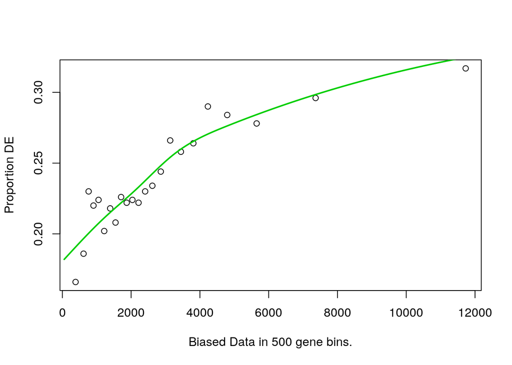

```r
head(pwf)
```

```
##                 DEgenes bias.data       pwf
## ENSG00000124208       0      1978 0.2277159
## ENSG00000224628       0      1510 0.2177040
## ENSG00000125835       0       954 0.2050858
## ENSG00000125834       0      6013 0.2874461
## ENSG00000197818       0      6295 0.2898577
## ENSG00000101181       0      2644 0.2431316
```

### Perform the enrichment analysis parametrically

Here we use a parametric test to look for differences in enrichment with respect to different categories. This is the 2 x 2 table approach. You can also use random sampling to define the null distribution by setting the parameters `method="Sampling"` and `repcnt=1000` for the number of null repititions.

```r
GO.wall=goseq(pwf,"hg19","ensGene")
```

```
## Fetching GO annotations...
```

```
## For 2096 genes, we could not find any categories. These genes will be excluded.
```

```
## To force their use, please run with use_genes_without_cat=TRUE (see documentation).
```

```
## This was the default behavior for version 1.15.1 and earlier.
```

```
## Calculating the p-values...
```

```r
head(GO.wall)
```

```
##         category over_represented_pvalue under_represented_pvalue
## 2162  GO:0005615            3.123682e-18                        1
## 10003 GO:0044421            7.281763e-18                        1
## 2142  GO:0005576            1.052930e-17                        1
## 13341 GO:0070062            4.042024e-16                        1
## 9539  GO:0043230            7.745002e-16                        1
## 16792 GO:1903561            7.745002e-16                        1
##       numDEInCat numInCat                      term ontology
## 2162         580     1745       extracellular space       CC
## 10003        599     1816 extracellular region part       CC
## 2142         646     1986      extracellular region       CC
## 13341        522     1578     extracellular exosome       CC
## 9539         523     1586   extracellular organelle       CC
## 16792        523     1586     extracellular vesicle       CC
```

### Limiting yourself to a single category you are interested in

Suppose there is a particular category or function you are interested in. You can limit to just that category

```r
GO.MF=goseq(pwf,"hg19","ensGene",test.cats=c("GO:MF"))
```

```
## Fetching GO annotations...
```

```
## For 2096 genes, we could not find any categories. These genes will be excluded.
```

```
## To force their use, please run with use_genes_without_cat=TRUE (see documentation).
```

```
## This was the default behavior for version 1.15.1 and earlier.
```

```
## Calculating the p-values...
```

```r
head(GO.MF)
```

```
##        category over_represented_pvalue under_represented_pvalue
## 1043 GO:0005515            4.506525e-08                1.0000000
## 946  GO:0005198            1.712080e-06                0.9999994
## 2977 GO:0050839            4.239095e-05                0.9999751
## 2706 GO:0045296            5.412440e-05                0.9999694
## 2009 GO:0023026            7.596136e-05                0.9999974
## 236  GO:0003723            9.069790e-05                0.9999307
##      numDEInCat numInCat                                 term ontology
## 1043       1767     6546                      protein binding       MF
## 946         129      364         structural molecule activity       MF
## 2977        113      315       cell adhesion molecule binding       MF
## 2706         95      259                     cadherin binding       MF
## 2009          8        9 MHC class II protein complex binding       MF
## 236         391     1338                          RNA binding       MF
```

## More information

Gene set and other enrichment analyses are widely used to make sense of genomic results. Here are a couple of good places to start

- [geneontology website](http://geneontology.org/)
- [goseq vignette](http://www.bioconductor.org/packages/release/bioc/vignettes/goseq/inst/doc/goseq.pdf)
- [seqGSEA package](http://www.bioconductor.org/packages/release/bioc/html/SeqGSEA.html)
- [An early gene set enrichment paper](http://www.pnas.org/content/102/43/15545.full)

It is also useful to compile the time the document was processed. This document was processed on: 2018-11-28.